# Lab 4 SPSS Output

[output not shown]

Log  
Log - Log - August 14, 2018

GET  
FILE='C:\Users\Heather\Desktop\R CSV Data\Biometrics\SPSS files\Earturn.sav'.  
DATASET NAME DataSet1 WINDOW=FRONT.  
GET  
FILE='C:\Users\Heather\Desktop\R CSV Data\Biometrics\SPSS files\Earturn.sav'.  
>Warning # 67. Command name: GET FILE  
>The document is already in use by another user or process. If you make  
>changes to the document they may overwrite changes made by others or your  
>changes may be overwritten by others.  
>File opened C:\Users\Heather\Desktop\R CSV Data\Biometrics\SPSS files\Earturn.sav  
DATASET NAME DataSet2 WINDOW=FRONT.  
DATASET CLOSE DataSet1.  
NPAR TESTS  
/BINOMIAL (0.50)=Ear  
/MISSING ANALYSIS.

NPar Tests  
NPar Tests - Binomial Test - August 14, 2018

Binomial TestBinomial Test, table, 1 levels of column headers and 2 levels of row headers, table with 7 columns and 5 rows

|  |  | Category | N | Observed Prop. | Test Prop. | Exact Sig. (2-tailed) |
| --- | --- | --- | --- | --- | --- | --- |
| Ear | Group 1 | right | 19 | .76 | .50 | .015 |
|  | Group 2 | left | 6 | .24 |  |  |
|  | Total |  | 25 | 1.00 |  |  |

Log  
Log - Log - August 14, 2018

NPAR TESTS  
/BINOMIAL (0.50)=Ear  
/MISSING ANALYSIS.

NPar Tests  
NPar Tests - Binomial Test - August 14, 2018

Binomial TestBinomial Test, table, 1 levels of column headers and 2 levels of row headers, table with 7 columns and 5 rows

|  |  | Category | N | Observed Prop. | Test Prop. | Exact Sig. (2-tailed) |
| --- | --- | --- | --- | --- | --- | --- |
| Ear | Group 1 | right | 18 | .72 | .50 | .043 |
|  | Group 2 | left | 7 | .28 |  |  |
|  | Total |  | 25 | 1.00 |  |  |

Log  
Log - Log - August 14, 2018

NPAR TESTS  
/BINOMIAL (0.50)=Ear  
/MISSING ANALYSIS.

NPar Tests  
NPar Tests - Binomial Test - August 14, 2018

Binomial TestBinomial Test, table, 1 levels of column headers and 2 levels of row headers, table with 7 columns and 5 rows

|  |  | Category | N | Observed Prop. | Test Prop. | Exact Sig. (2-tailed) |
| --- | --- | --- | --- | --- | --- | --- |
| Ear | Group 1 | right | 17 | .68 | .50 | .108 |
|  | Group 2 | left | 8 | .32 |  |  |
|  | Total |  | 25 | 1.00 |  |  |

Log  
Log - Log - August 14, 2018

GET  
FILE='C:\Users\Heather\Desktop\R CSV Data\Biometrics\SPSS files\Spermatogenesis.sav'.  
DATASET NAME DataSet3 WINDOW=FRONT.  
FREQUENCIES VARIABLES=chromosome  
/BARCHART FREQ  
/ORDER=ANALYSIS.

Frequencies  
Frequencies - Active Dataset - August 14, 2018

[DataSet3] C:\Users\Heather\Desktop\R CSV Data\Biometrics\SPSS files\Spermatogenesis.sav

Frequencies  
Frequencies - Statistics - August 14, 2018

StatisticsStatistics, table, chromosome, 1 layers, 0 levels of column headers and 2 levels of row headers, table with 3 columns and 4 rows

| chromosome chromosome |  |  |
| --- | --- | --- |
| N | Valid | 25 |
|  | Missing | 0 |

Frequencies  
Frequencies - chromosome - August 14, 2018

chromosomechromosome, table, 1 levels of column headers and 2 levels of row headers, table with 6 columns and 13 rows

|  |  | Frequency | Percent | Valid Percent | Cumulative Percent |
| --- | --- | --- | --- | --- | --- |
| Valid | 04 | 2 | 8.0 | 8.0 | 8.0 |
|  | 06 | 3 | 12.0 | 12.0 | 20.0 |
|  | 07 | 1 | 4.0 | 4.0 | 24.0 |
|  | 09 | 1 | 4.0 | 4.0 | 28.0 |
|  | 10 | 1 | 4.0 | 4.0 | 32.0 |
|  | 11 | 1 | 4.0 | 4.0 | 36.0 |
|  | 14 | 2 | 8.0 | 8.0 | 44.0 |
|  | 15 | 1 | 4.0 | 4.0 | 48.0 |
|  | X | 10 | 40.0 | 40.0 | 88.0 |
|  | Y | 3 | 12.0 | 12.0 | 100.0 |
|  | Total | 25 | 100.0 | 100.0 |  |

Frequencies  
Frequencies - Bar Chart - August 14, 2018

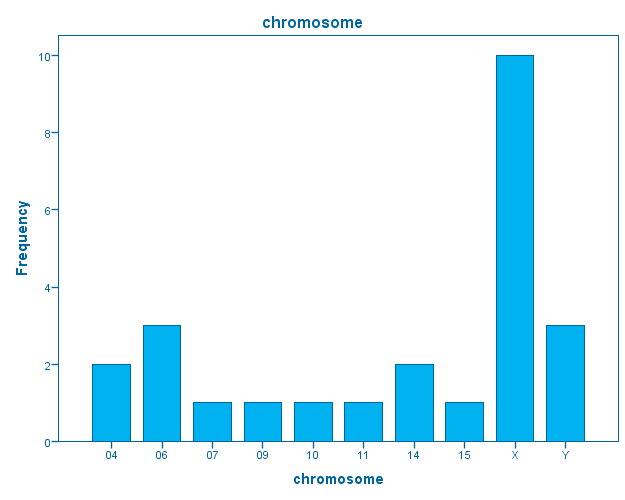

Log  
Log - Log - August 14, 2018

SORT CASES BY onX (A).  
NPAR TESTS  
/BINOMIAL (0.061)=onX  
/MISSING ANALYSIS.

NPar Tests  
NPar Tests - Binomial Test - August 14, 2018

Binomial TestBinomial Test, table, 1 levels of column headers and 2 levels of row headers, table with 7 columns and 5 rows

|  |  | Category | N | Observed Prop. | Test Prop. | Exact Sig. (1-tailed) |
| --- | --- | --- | --- | --- | --- | --- |
| onX | Group 1 | yes | 10 | .400 | .061 | .00000099 |
|  | Group 2 | no | 15 | .600 |  |  |
|  | Total |  | 25 | 1.000 |  |  |

Log  
Log - Log - August 14, 2018

SORT CASES BY onY (A).  
NPAR TESTS  
/BINOMIAL (0.012)=onY  
/MISSING ANALYSIS.

NPar Tests  
NPar Tests - Binomial Test - August 14, 2018

Binomial TestBinomial Test, table, 1 levels of column headers and 2 levels of row headers, table with 7 columns and 5 rows

|  |  | Category | N | Observed Prop. | Test Prop. | Exact Sig. (1-tailed) |
| --- | --- | --- | --- | --- | --- | --- |
| onY | Group 1 | yes | 3 | .120 | .012 | .00326 |
|  | Group 2 | no | 22 | .880 |  |  |
|  | Total |  | 25 | 1.000 |  |  |

Log  
Log - Log - August 14, 2018

GET  
FILE='C:\Users\Heather\Desktop\R CSV Data\Biometrics\SPSS files\Wallets.sav'.  
>Warning # 5281. Command name: GET FILE  
>SPSS Statistics is running in Unicode encoding mode. This file is encoded in  
>a locale-specific (code page) encoding. The defined width of any string  
>variables are automatically tripled in order to avoid possible data loss. You  
>can use ALTER TYPE to set the width of string variables to the width of the  
>longest observed value for each string variable.  
DATASET NAME DataSet4 WINDOW=FRONT.  
SORT CASES BY wallet_returned (A).  
SORT CASES BY wallet_returned (D).  
NPAR TESTS  
/BINOMIAL (0.50)=wallet_returned  
/MISSING ANALYSIS.

NPar Tests  
NPar Tests - Active Dataset - August 14, 2018

[DataSet4] C:\Users\Heather\Desktop\R CSV Data\Biometrics\SPSS files\Wallets.sav

NPar Tests  
NPar Tests - Binomial Test - August 14, 2018

Binomial TestBinomial Test, table, 1 levels of column headers and 2 levels of row headers, table with 7 columns and 5 rows

|  |  | Category | N | Observed Prop. | Test Prop. | Exact Sig. (2-tailed) |
| --- | --- | --- | --- | --- | --- | --- |
| Was the wallet returned? | Group 1 | returned | 101 | .42 | .50 | .017 |
|  | Group 2 | not returned | 139 | .58 |  |  |
|  | Total |  | 240 | 1.00 |  |  |

Log  
Log - Log - August 14, 2018

SORT CASES BY sideDown (D).  
NPAR TESTS  
/BINOMIAL (0.62)=sideDown  
/MISSING ANALYSIS.

NPar Tests  
NPar Tests - Binomial Test - August 14, 2018

Binomial TestBinomial Test, table, 1 levels of column headers and 2 levels of row headers, table with 7 columns and 5 rows

|  |  | Category | N | Observed Prop. | Test Prop. | Exact Sig. (1-tailed) |
| --- | --- | --- | --- | --- | --- | --- |
| sideDown | Group 1 | butter side | 6101 | .62 | .62 | .406 |
|  | Group 2 | dry side | 3720 | .38 |  |  |
|  | Total |  | 9821 | 1.00 |  |  |

Log  
Log - Log - August 14, 2018

EXAMINE VARIABLES=sideDown  
/PLOT BOXPLOT STEMLEAF  
/COMPARE GROUPS  
/STATISTICS DESCRIPTIVES  
/CINTERVAL 95  
/MISSING LISTWISE  
/NOTOTAL.

Explore  
Explore - Case Processing Summary - August 14, 2018

Case Processing SummaryCase Processing Summary, table, 3 levels of column headers and 1 levels of row headers, table with 7 columns and 5 rows

|  | Cases |  |  |  |  |  |
| --- | --- | --- | --- | --- | --- | --- |
|  | Valid |  | Missing |  | Total |  |
|  | N | Percent | N | Percent | N | Percent |
| sideDown | 9821 | 100.0% | 0 | 0.0% | 9821 | 100.0% |

Explore  
Explore - Descriptives - August 14, 2018

DescriptivesDescriptives, table, 1 levels of column headers and 3 levels of row headers, table with 5 columns and 15 rows

|  |  |  | Statistic | Std. Error |
| --- | --- | --- | --- | --- |
| sideDown | Mean |  | .62 | .005 |
|  | 95% Confidence Interval for Mean | Lower Bound | .61 |  |
|  |  | Upper Bound | .63 |  |
|  | 5% Trimmed Mean |  | .63 |  |
|  | Median |  | 1.00 |  |
|  | Variance |  | .235 |  |
|  | Std. Deviation |  | .485 |  |
|  | Minimum |  | 0 |  |
|  | Maximum |  | 1 |  |
|  | Range |  | 1 |  |
|  | Interquartile Range |  | 1 |  |
|  | Skewness |  | -.500 | .025 |
|  | Kurtosis |  | -1.750 | .049 |

sideDown  
sideDown - Stem-and-Leaf Plot - August 14, 2018

sideDown Stem-and-Leaf Plot  
Frequency Stem & Leaf  
3720.00 0 . 00000000000000000000000000000000000000000000000000000000000000  
.00 0 .  
.00 1 .  
.00 1 .  
.00 2 .  
.00 2 .  
.00 3 .  
.00 3 .  
.00 4 .  
.00 4 .  
.00 5 .  
.00 5 .  
.00 6 .  
.00 6 .  
.00 7 .  
.00 7 .  
.00 8 .  
.00 8 .  
.00 9 .  
.00 9 .  
6101.00 10 . 000000000000000000000000000000000000000000000000000000000000000000000000000000000000000000000000000000  
Stem width: 0  
Each leaf: 60 case(s)

sideDown  
sideDown - Boxplot - August 14, 2018

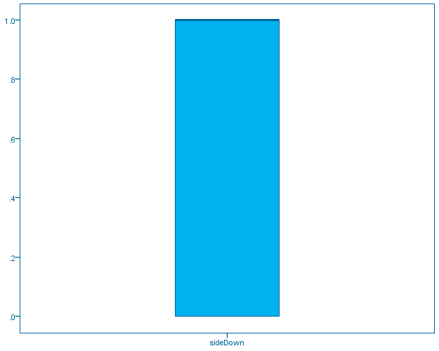

Log  
Log - Log - August 14, 2018

NPAR TESTS  
/BINOMIAL (0.5)=sideDown  
/STATISTICS DESCRIPTIVES  
/MISSING ANALYSIS.

NPar Tests  
NPar Tests - Descriptive Statistics - August 14, 2018

Descriptive StatisticsDescriptive Statistics, table, 1 levels of column headers and 1 levels of row headers, table with 6 columns and 3 rows

|  | N | Mean | Std. Deviation | Minimum | Maximum |
| --- | --- | --- | --- | --- | --- |
| sideDown | 9821 | .62 | .485 | 0 | 1 |

NPar Tests  
NPar Tests - Binomial Test - August 14, 2018

Binomial TestBinomial Test, table, 1 levels of column headers and 2 levels of row headers, table with 7 columns and 5 rows

|  |  | Category | N | Observed Prop. | Test Prop. | Exact Sig. (2-tailed) |
| --- | --- | --- | --- | --- | --- | --- |
| sideDown | Group 1 | butter side | 6101 | .62 | .50 | .000 |
|  | Group 2 | dry side | 3720 | .38 |  |  |
|  | Total |  | 9821 | 1.00 |  |  |

Log  
Log - Log - August 14, 2018

GET  
FILE='C:\Users\Heather\Desktop\R CSV Data\Biometrics\SPSS files\Countries.sav'.  
DATASET NAME DataSet8 WINDOW=FRONT.  
* Chart Builder.  
GGRAPH  
/GRAPHDATASET NAME="graphdataset" VARIABLES=Immunization_DPT MISSING=LISTWISE REPORTMISSING=NO  
/GRAPHSPEC SOURCE=INLINE.  
BEGIN GPL  
SOURCE: s=userSource(id("graphdataset"))  
DATA: Immunization_DPT=col(source(s), name("Immunization_DPT"))  
GUIDE: axis(dim(1), label("Immunization DPT (%of children ages 12-23 months)"))  
GUIDE: axis(dim(2), label("Frequency"))  
ELEMENT: interval(position(summary.count(bin.rect(Immunization_DPT))),  
shape.interior(shape.square))  
END GPL.

GGraph  
GGraph - Active Dataset - August 14, 2018

[DataSet8] C:\Users\Heather\Desktop\R CSV Data\Biometrics\SPSS files\Countries.sav

GGraph  
GGraph - Graph - August 14, 2018

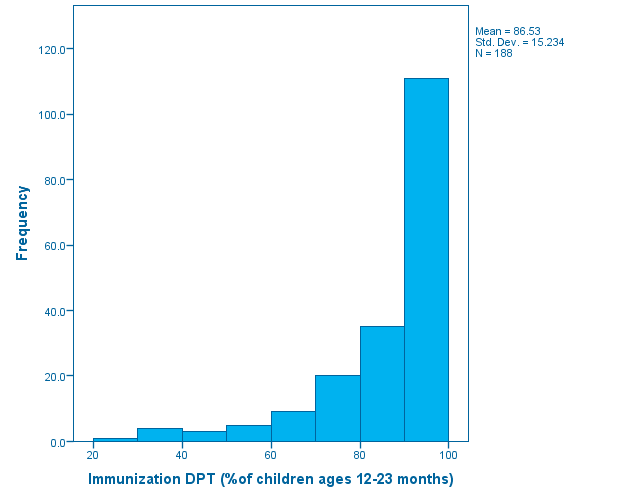

Log  
Log - Log - August 14, 2018

FREQUENCIES VARIABLES=Personalcomputers Internet_users  
/FORMAT=NOTABLE  
/STATISTICS=STDDEV SEMEAN MEAN  
/HISTOGRAM  
/ORDER=ANALYSIS.

Frequencies  
Frequencies - Statistics - August 14, 2018

StatisticsStatistics, table, 1 levels of column headers and 2 levels of row headers, table with 4 columns and 7 rows

|  |  | Personal computers per 100 people | Internet users per 100 people |
| --- | --- | --- | --- |
| N | Valid | 179 | 190 |
|  | Missing | 30 | 19 |
| Mean |  | 15.01 | 19.22 |
| Std. Error of Mean |  | 1.601 | 1.485 |
| Std. Deviation |  | 21.420 | 20.464 |

Histogram  
Histogram - Personal computers per 100 people - August 14, 2018

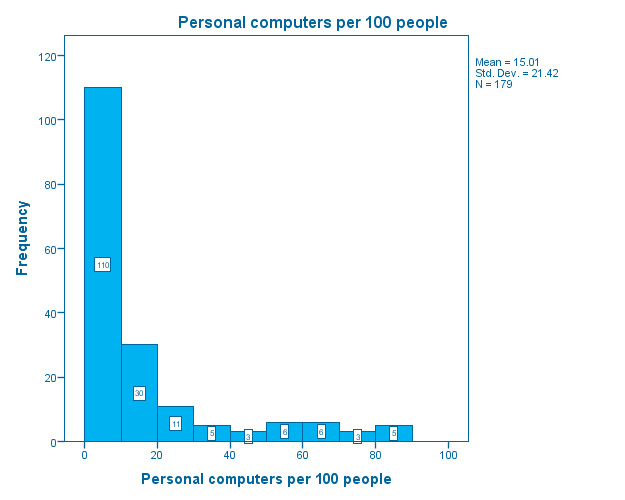

Histogram  
Histogram - Internet users per 100 people - August 14, 2018

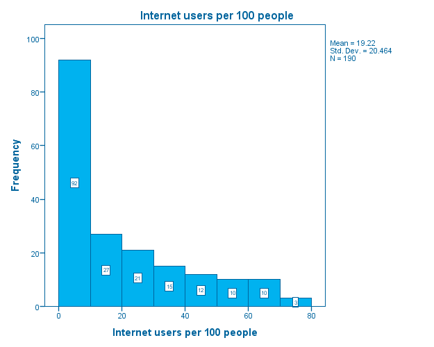

Log  
Log - Log - August 14, 2018

DESCRIPTIVES VARIABLES=Life_expectancy_birth_female Life_expectancy_birth_male  
Life_expectancy_birth_totalyears  
/STATISTICS=MEAN STDDEV MIN MAX SEMEAN.

Descriptives  
Descriptives - Descriptive Statistics - August 14, 2018

Descriptive StatisticsDescriptive Statistics, table, 2 levels of column headers and 1 levels of row headers, table with 7 columns and 7 rows

|  | N | Minimum | Maximum | Mean |  | Std. Deviation |
| --- | --- | --- | --- | --- | --- | --- |
|  | Statistic | Statistic | Statistic | Statistic | Std. Error | Statistic |
| Life expectancy at birth (female) | 187 | 41 | 86 | 70.06 | .852 | 11.656 |
| Life expectancy at birth (male) | 186 | 40 | 79 | 65.42 | .765 | 10.432 |
| Life expectancy at birth (total) | 185 | 41 | 82 | 67.66 | .810 | 11.022 |
| Valid N (listwise) | 185 |  |  |  |  |  |

Log  
Log - Log - August 14, 2018

EXAMINE VARIABLES=Population_female  
/PLOT BOXPLOT STEMLEAF  
/COMPARE GROUPS  
/STATISTICS DESCRIPTIVES  
/CINTERVAL 95  
/MISSING LISTWISE  
/NOTOTAL.

Explore  
Explore - Case Processing Summary - August 14, 2018

Case Processing SummaryCase Processing Summary, table, 3 levels of column headers and 1 levels of row headers, table with 7 columns and 5 rows

|  | Cases |  |  |  |  |  |
| --- | --- | --- | --- | --- | --- | --- |
|  | Valid |  | Missing |  | Total |  |
|  | N | Percent | N | Percent | N | Percent |
| Population female (% of total) | 188 | 90.0% | 21 | 10.0% | 209 | 100.0% |

Explore  
Explore - Descriptives - August 14, 2018

DescriptivesDescriptives, table, 1 levels of column headers and 3 levels of row headers, table with 5 columns and 15 rows

|  |  |  | Statistic | Std. Error |
| --- | --- | --- | --- | --- |
| Population female (% of total) | Mean |  | 49.89 | .176 |
|  | 95% Confidence Interval for Mean | Lower Bound | 49.55 |  |
|  |  | Upper Bound | 50.24 |  |
|  | 5% Trimmed Mean |  | 50.12 |  |
|  | Median |  | 50.00 |  |
|  | Variance |  | 5.796 |  |
|  | Std. Deviation |  | 2.408 |  |
|  | Minimum |  | 32 |  |
|  | Maximum |  | 54 |  |
|  | Range |  | 22 |  |
|  | Interquartile Range |  | 2 |  |
|  | Skewness |  | -4.540 | .177 |
|  | Kurtosis |  | 29.738 | .353 |

Population female (% of total)  
Population female (% of total) - Stem-and-Leaf Plot - August 14, 2018

Population female (% of total) Stem-and-Leaf Plot  
Frequency Stem & Leaf  
6.00 Extremes (=<45)  
1.00 47 . 0  
.00 47 .  
8.00 48 . 00000000  
.00 48 .  
33.00 49 . 000000000000000000000000000000000  
.00 49 .  
77.00 50 . 00000000000000000000000000000000000000000000000000000000000000000000000000000  
.00 50 .  
43.00 51 . 0000000000000000000000000000000000000000000  
.00 51 .  
11.00 52 . 00000000000  
.00 52 .  
6.00 53 . 000000  
.00 53 .  
3.00 54 . 000  
Stem width: 1  
Each leaf: 1 case(s)

Population female (% of total)  
Population female (% of total) - Boxplot - August 14, 2018

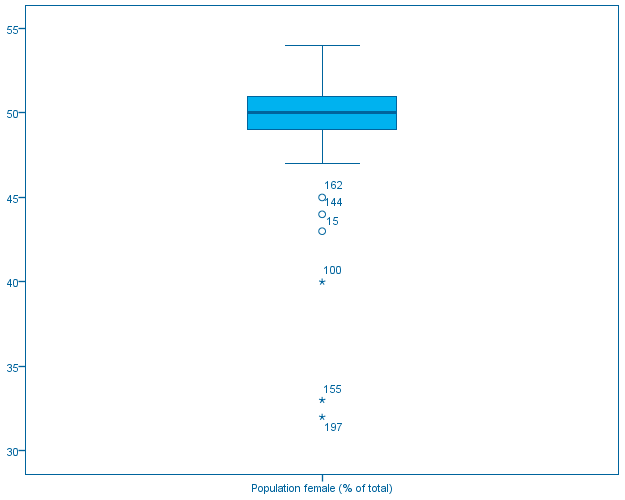

[output not shown]

[output not shown]

[output not shown]

[output not shown]

[output not shown]

[output not shown]